# Do the three methods differ in community composition? (Study B, Question 1)

> **What this document is.** The first Study B question: do pill, injectable and vaginal ring users have differently *composed* vaginal microbiomes? This is the microbiome half of the week — the same kind of analysis as Tuesday’s ordination module, but now testing the three arms against each other. We start with a map (ordination), then a formal test of the map (PERMANOVA), then ask whether any individual species differ (DESeq2 on raw counts). Full data QC lives in `01-qc.html`; this document repeats only the checks this analysis depends on.

```r
library(tidyverse)
library(here)
library(DESeq2)
library(microViz)
library(phyloseq)
library(vegan)
library(patchwork)   # lets p_arm + p_com put two plots side by side

source(here("R/count_tables.R"))

d  <- read_counts("group_b")
sp <- d$species         # 220 species x 93 samples, RAW counts
md <- d$metadata        # one row per sample, same order as the columns

# Community type, same rule as 01-qc and notebook 02: Lactobacillus genus
# >= half of the sample's species reads. Used only to label the right-hand
# ordination panel — the tests below use arm, from the metadata.
lacto_taxa <- d$taxonomy |> filter(Genus == "Lactobacillus") |> pull(taxon)
lacto_frac <- colSums(sp[lacto_taxa, , drop = FALSE]) / colSums(sp)
md$community <- ifelse(lacto_frac >= 0.5, "lactobacillus", "anaerobe")
```

# 1. QC for this analysis

```r
stopifnot(identical(colnames(sp), md$sample_id))  # order check: a silent
                                                  # mismatch would ruin everything
knitr::kable(table(Arm = md$arm, `RNA-seq batch` = md$rnaseq_batch),
             caption = "Samples per arm and sequencing batch")
```

Samples per arm and sequencing batch

|  | B1 | B2 |
| --- | --- | --- |
| injectable | 20 | 19 |
| pill | 14 | 14 |
| ring | 13 | 13 |

- **Order check passed:** species-table columns and metadata rows are in the same `sample_id` order.
- **Sample sizes:** 28 pill, 39 injectable, 26 ring (93 total). The ring arm is the smallest, so ring comparisons carry the least power.
- **Carried flags from `01-qc.html`:** nine samples sit below half the median microbiome library size (lowest `B006` at 5,247 reads); `B030` is 99.8 % *Lactobacillus iners* (real biology, but it can pull ordinations); `B018` and `B029` lack cytokines (irrelevant here). None is dropped — the ordination in section 2 is the check that no flagged sample sits wildly alone.

# 2. Ordination: do the three arms separate?

We transform to CLR (centred log-ratio — each species compared against the geometric mean of the sample, the standard way to handle compositional data) and draw a Euclidean PCoA. Points are coloured by arm; the right panel reminds us what the *big* structure in this table actually is: community type, not method.

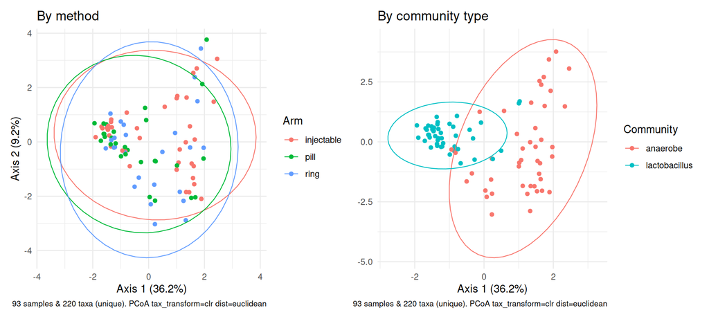

Species-table PCoA (CLR + Euclidean). Left: coloured by method. Right: coloured by community type — the structure that actually separates.

```r
ps <- as_counts(dataset = "group_b", table = "microbiome", data = d)
sd <- as(sample_data(ps), "data.frame")
idx <- match(sd$sample_id, md$sample_id)
sd$arm       <- md$arm[idx]
sd$community <- md$community[idx]
sample_data(ps) <- sample_data(sd)

ord <- ps |>
  tax_transform("clr", zero_replace = "halfmin") |>
  dist_calc("euclidean") |>
  ord_calc("PCoA")

eig <- attr(ord, "ord")$CA$eig
sh  <- round(100 * eig / sum(eig), 1)

p_arm <- ord_plot(ord, axes = 1:2, color = "arm") +
  stat_ellipse(aes(colour = arm), type = "norm", linewidth = 0.4) +
  labs(title = "By method", x = sprintf("Axis 1 (%s%%)", sh[1]),
       y = sprintf("Axis 2 (%s%%)", sh[2]), colour = "Arm")
p_com <- ord_plot(ord, axes = 1:2, color = "community") +
  stat_ellipse(aes(colour = community), type = "norm", linewidth = 0.4) +
  labs(title = "By community type", x = sprintf("Axis 1 (%s%%)", sh[1]),
       y = NULL, colour = "Community")
p_arm + p_com
```

No sample sits in obvious isolation, so none of the flagged low-depth samples needs dropping.

# 3. PERMANOVA: a formal test of the map

PERMANOVA asks whether samples from different arms are further apart, on average, than samples from the same arm, and gets a p-value by shuffling the arm labels 9,999 times. R² is the share of all the between-sample variation the arm explains. Batch is included in the same model with `by = "margin"` so each term gets its own adjusted test ([Anderson 2001](https://doi.org/10.1111/j.1442-9993.2001.01070.pp.x)).

```r
dm <- attr(ord, "dist")
meta_p <- data.frame(sample_data(ps))[rownames(as.matrix(dm)), ]
meta_p$arm <- factor(meta_p$arm, levels = c("ring", "pill", "injectable"))
set.seed(1)
main <- adonis2(dm ~ arm + rnaseq_batch, data = meta_p,
                permutations = 9999, by = "margin")
disp <- permutest(betadisper(dm, meta_p$arm), permutations = 9999)

pair <- function(a, b) {
  keep <- meta_p$arm %in% c(a, b)
  out  <- adonis2(as.dist(as.matrix(dm)[keep, keep]) ~ arm,
                  data = droplevels(meta_p[keep, ]), permutations = 9999)
  tibble(comparison = paste(a, "vs", b),
         n = sum(keep),
         `share of variation (%)` = round(100 * out$R2[1], 1),
         `p (raw)` = out$`Pr(>F)`[1])
}
pairs <- bind_rows(pair("ring", "pill"),
                   pair("ring", "injectable"),
                   pair("pill", "injectable")) |>
  mutate(`p (adjusted, BH)` = p.adjust(`p (raw)`, "BH"))

q1_r2  <- round(100 * main$R2[1], 1)   # row 1 = arm (margin test)
q1_p   <- round(main$`Pr(>F)`[1], 3)
q1_rp  <- round(pairs$`p (raw)`[2], 3)
q1_ra  <- round(pairs$`p (adjusted, BH)`[2], 3)
q1_sp2 <- pairs$`share of variation (%)`[2]
q1_dp  <- round(disp$tab$`Pr(>F)`[1], 2)
```

```r
knitr::kable(
  tibble(
    test = c("arm (adjusted for batch)", "batch (adjusted for arm)",
             "spread check (betadisper)"),
    n = c(93, 93, 93),
    `share of variation (%)` = round(100 * c(main$R2[1], main$R2[2], NA), 1),
    p = round(c(main$`Pr(>F)`[1], main$`Pr(>F)`[2],
                disp$tab$`Pr(>F)`[1]), 3)
  ),
  caption = "PERMANOVA on species (CLR + Euclidean, 9,999 permutations)"
)
```

PERMANOVA on species (CLR + Euclidean, 9,999 permutations)

| test | n | share of variation (%) | p |
| --- | --- | --- | --- |
| arm (adjusted for batch) | 93 | 2.8 | 0.175 |
| batch (adjusted for arm) | 93 | 0.8 | 0.614 |
| spread check (betadisper) | 93 | NA | 0.895 |

```r
knitr::kable(pairs |>
               mutate(`p (raw)` = round(`p (raw)`, 3),
                      `p (adjusted, BH)` = round(`p (adjusted, BH)`, 3)),
             caption = "Each pair of arms separately (9,999 permutations)")
```

Each pair of arms separately (9,999 permutations)

| comparison | n | share of variation (%) | p (raw) | p (adjusted, BH) |
| --- | --- | --- | --- | --- |
| ring vs pill | 54 | 1.7 | 0.445 | 0.445 |
| ring vs injectable | 65 | 1.7 | 0.309 | 0.445 |
| pill vs injectable | 67 | 2.7 | 0.084 | 0.251 |

> **Sanity check.** Change `set.seed(1)` to another number and re-render — the R² must stay exactly 2.8 % and the p-value should stay near 0.175. You can also verify the R² by hand: it is the between-arm sum of squares divided by the total, both printed by `adonis2`.

# 4. Differential abundance: do any individual species differ?

```r
sp_f <- sp[rowSums(sp >= 10) >= 10, ]    # same filter rule as the gene analyses
dds <- DESeq(DESeqDataSetFromMatrix(sp_f, md, design = ~ rnaseq_batch + arm),
             quiet = TRUE)
lrt <- as.data.frame(results(DESeq(DESeqDataSetFromMatrix(sp_f, md, ~ rnaseq_batch + arm),
                                   test = "LRT", reduced = ~ rnaseq_batch,
                                   quiet = TRUE))) |>
  rownames_to_column("taxon") |>
  left_join(d$taxonomy |> select(taxon, Genus, species), by = "taxon") |>
  mutate(padj = replace_na(padj, 1))

pair_res <- function(a, b) {
  as.data.frame(results(dds, contrast = c("arm", a, b))) |>
    rownames_to_column("taxon") |>
    left_join(d$taxonomy |> select(taxon, Genus, species), by = "taxon") |>
    mutate(padj = replace_na(padj, 1))
}
ring_pill <- pair_res("ring", "pill")
ring_inj  <- pair_res("ring", "injectable")
pill_inj  <- pair_res("pill", "injectable")
```

```r
expected <- function(r) round(0.05 * sum(!is.na(r$pvalue)))
knitr::kable(
  tibble(
    comparison = c("any arm differs (LRT)", "ring vs pill", "ring vs injectable",
                   "pill vs injectable"),
    samples = c("93", "26 vs 28", "26 vs 39", "28 vs 39"),
    `species at FDR < 0.05` = c(sum(lrt$padj < 0.05),
                                sum(ring_pill$padj < 0.05),
                                sum(ring_inj$padj < 0.05),
                                sum(pill_inj$padj < 0.05)),
    `raw p < 0.05` = c(sum(lrt$pvalue < 0.05, na.rm = TRUE),
                       sum(ring_pill$pvalue < 0.05, na.rm = TRUE),
                       sum(ring_inj$pvalue < 0.05, na.rm = TRUE),
                       sum(pill_inj$pvalue < 0.05, na.rm = TRUE)),
    `expected by chance` = c(expected(lrt), expected(ring_pill),
                             expected(ring_inj), expected(pill_inj))
  ),
  caption = "DESeq2 on species (raw counts, batch-adjusted)"
)
```

DESeq2 on species (raw counts, batch-adjusted)

| comparison | samples | species at FDR < 0.05 | raw p < 0.05 | expected by chance |
| --- | --- | --- | --- | --- |
| any arm differs (LRT) | 93 | 1 | 5 | 2 |
| ring vs pill | 26 vs 28 | 0 | 5 | 2 |
| ring vs injectable | 26 vs 39 | 3 | 5 | 2 |
| pill vs injectable | 28 vs 39 | 6 | 9 | 2 |

```r
top <- lrt |> filter(padj < 0.05) |>
  slice_min(padj, n = 10) |>
  transmute(species = str_c(Genus, " ", species),
            FDR = signif(padj, 2))
knitr::kable(top, caption = "Smallest-FDR species in the any-arm test")
```

Smallest-FDR species in the any-arm test

| species | FDR |
| --- | --- |
| Candidatus Lachnocurva Candidatus Lachnocurva_vaginae (BVAB1) | 8.6e-05 |

# 5. Verdict

## Choices made

- **CLR + Euclidean** for the ordination and PERMANOVA, because species profiles are compositional; Bray-Curtis on raw counts and Jaccard on presence/absence were the alternatives and give the same picture (see `01-qc.html`, section 9).
- **Species table left unfiltered** for the ordination, matching `01-qc.html`; the DESeq2 abundance test filters at ≥ 10 reads in ≥ 10 samples, the same rule as the gene analyses — a laxer rule spends tests on near-empty species, a stricter one loses power.
- **PERMANOVA with batch in one model, `by = "margin"`, 9,999 permutations** — the correction from `03-three-arms-review.html`; the default sequential test gives the first term credit for anything it shares with the second. The batch label is the RNA-seq run, the only batch information the metadata carries; if the microbiome was sequenced in different runs, that variable is not available to adjust for.
- **Likelihood-ratio test** for “does any arm differ?” (2 df) before any pairwise look; jumping straight to pairwise tests is the alternative and invites cherry-picking.
- **BH adjustment** for the pairwise PERMANOVA p-values; Bonferroni is the stricter alternative.
- **Kept all 93 samples**, including the nine low-depth ones and the `B030` near-monoculture; dropping them is the alternative but none drives the (null) result, and CLR with half-min replacement handles the zeros.
- **Did not adjust for vaginal pH** here — pH differs by arm (p = 0.02) and could be on the causal path from hormones to microbiome; an adjusted model is the alternative and belongs in a follow-up rather than a null-result document.